# K-means sobre el dataset ampliado de Shapes (Ejercicio 1.4)

En este notebook se utiliza el dataset de 100 elementos generado mediante oversampling sintético.  
El objetivo es:

1. Cargar el CSV desde GitHub.
2. Preparar las variables categóricas para aplicar K-means.
3. Calcular una propuesta de `k` óptima mediante el método del codo y la silueta.
4. Aplicar el algoritmo K-means.
5. Analizar los clusters resultantes.

```python
import pandas as pd
import numpy as np
import matplotlib.pyplot as plt

from sklearn.cluster import KMeans
from sklearn.metrics import silhouette_score
from sklearn.decomposition import PCA

try:
    from sklearn.preprocessing import OneHotEncoder
    encoder_kwargs = {"sparse_output": False, "handle_unknown": "ignore"}
except TypeError:
    from sklearn.preprocessing import OneHotEncoder
    encoder_kwargs = {"sparse": False, "handle_unknown": "ignore"}

RANDOM_STATE = 26
```

## 1. Carga del dataset

El dataset se carga directamente desde el archivo CSV publicado en GitHub.  
Como el archivo está delimitado por punto y coma (`;`), se indica `sep=";"` en `read_csv`.

```python
from pandas.api.types import is_object_dtype, is_string_dtype

# URL del dataset en formato raw
url = "https://raw.githubusercontent.com/danielagarciachavero/AC/refs/heads/main/PR/DanielaGarciaChavero_EJ1_3.csv"

# Cargamos el CSV utilizando el separador correcto
df = pd.read_csv(url, sep=";")

# Limpiamos posibles espacios en los nombres de columnas y valores de texto
df.columns = df.columns.str.strip()

for col in df.columns:
    if is_object_dtype(df[col]) or is_string_dtype(df[col]):
        df[col] = df[col].astype("string").str.strip()

print("Dimensiones del dataset:", df.shape)
display(df.head(16))
```

```
Dimensiones del dataset: (100, 5)
```

|  | Forma | Numero_lados | Color | Tamano | Direccion |
| --- | --- | --- | --- | --- | --- |
| 0 | Triangulo | 3 | Amarillo | Grande | Arriba |
| 1 | Circulo | 0 | Rojo | Grande | Ninguna |
| 2 | Rectangulo | 4 | Verde | Mediano | Horizontal |
| 3 | Triangulo | 3 | Azul | Grande | Derecha |
| 4 | Cuadrado | 4 | Rojo | Grande | Ninguna |
| 5 | Cuadrado | 4 | Amarillo | Mediano | Ninguna |
| 6 | Circulo | 0 | Verde | Mediano | Ninguna |
| 7 | Rectangulo | 4 | Rojo | Pequeno | Vertical |
| 8 | Cuadrado | 4 | Verde | Grande | Ninguna |
| 9 | Triangulo | 3 | Rojo | Grande | Derecha |
| 10 | Rectangulo | 4 | Amarillo | Mediano | Diagonal ascendente |
| 11 | Triangulo | 3 | Verde | Pequeno | Arriba |
| 12 | Circulo | 0 | Amarillo | Mediano | Ninguna |
| 13 | Rectangulo | 4 | Verde | Grande | Horizontal |
| 14 | Circulo | 0 | Azul | Grande | Ninguna |
| 15 | Cuadrado | 4 | Azul | Grande | Ninguna |

## 2. Revisión básica del dataset

Se comprueba que el dataset tenga 100 registros y que las columnas coincidan con los atributos definidos: `Forma`, `Numero_lados`, `Color`, `Tamano` y `Direccion`.

```python
columnas_esperadas = ["Forma", "Numero_lados", "Color", "Tamano", "Direccion"]

# Validamos que estén todas las columnas esperadas
columnas_faltantes = [col for col in columnas_esperadas if col not in df.columns]

if columnas_faltantes:
    raise ValueError(f"Faltan columnas en el dataset: {columnas_faltantes}")

df = df[columnas_esperadas].copy()

print("Número de registros:", len(df))
print("\nValores nulos por columna:")
display(df.isna().sum())

print("\nDistribución de formas:")
display(df["Forma"].value_counts())

print("\nDistribución de colores:")
display(df["Color"].value_counts())

print("\nDistribución de tamaños:")
display(df["Tamano"].value_counts())

print("\nDistribución de direcciones:")
display(df["Direccion"].value_counts())
```

```
Número de registros: 100

Valores nulos por columna:
```

```
Forma           0
Numero_lados    0
Color           0
Tamano          0
Direccion       0
dtype: int64
```

```
Distribución de formas:
```

```
Forma
Triangulo     25
Circulo       25
Rectangulo    25
Cuadrado      25
Name: count, dtype: int64[pyarrow]
```

```
Distribución de colores:
```

```
Color
Verde       31
Amarillo    25
Rojo        25
Azul        19
Name: count, dtype: int64[pyarrow]
```

```
Distribución de tamaños:
```

```
Tamano
Grande     56
Mediano    31
Pequeno    13
Name: count, dtype: int64[pyarrow]
```

```
Distribución de direcciones:
```

```
Direccion
Ninguna                50
Arriba                 13
Horizontal             13
Derecha                12
Vertical                6
Diagonal ascendente     6
Name: count, dtype: int64[pyarrow]
```

## 3. Preparación de los datos para K-means

K-means trabaja con variables numéricas. Como este dataset contiene variables categóricas, se utiliza **one-hot encoding** para convertir cada categoría en una columna binaria.

Aunque `Numero_lados` es numérica, aquí se trata como variable categórica porque depende directamente de la forma y no representa una escala continua.

```python
# Tratamos todas las variables como categóricas para evitar relaciones ordinales artificiales
X_categorico = df.astype(str)

encoder = OneHotEncoder(**encoder_kwargs)
X = encoder.fit_transform(X_categorico)

feature_names = encoder.get_feature_names_out(columnas_esperadas)
X_encoded = pd.DataFrame(X, columns=feature_names)

print("Dimensiones después del one-hot encoding:", X_encoded.shape)
display(X_encoded.head())
```

```
Dimensiones después del one-hot encoding: (100, 20)
```

|  | Forma_Circulo | Forma_Cuadrado | Forma_Rectangulo | Forma_Triangulo | Numero_lados_0 | Numero_lados_3 | Numero_lados_4 | Color_Amarillo | Color_Azul | Color_Rojo | Color_Verde | Tamano_Grande | Tamano_Mediano | Tamano_Pequeno | Direccion_Arriba | Direccion_Derecha | Direccion_Diagonal ascendente | Direccion_Horizontal | Direccion_Ninguna | Direccion_Vertical |
| --- | --- | --- | --- | --- | --- | --- | --- | --- | --- | --- | --- | --- | --- | --- | --- | --- | --- | --- | --- | --- |
| 0 | 0.0 | 0.0 | 0.0 | 1.0 | 0.0 | 1.0 | 0.0 | 1.0 | 0.0 | 0.0 | 0.0 | 1.0 | 0.0 | 0.0 | 1.0 | 0.0 | 0.0 | 0.0 | 0.0 | 0.0 |
| 1 | 1.0 | 0.0 | 0.0 | 0.0 | 1.0 | 0.0 | 0.0 | 0.0 | 0.0 | 1.0 | 0.0 | 1.0 | 0.0 | 0.0 | 0.0 | 0.0 | 0.0 | 0.0 | 1.0 | 0.0 |
| 2 | 0.0 | 0.0 | 1.0 | 0.0 | 0.0 | 0.0 | 1.0 | 0.0 | 0.0 | 0.0 | 1.0 | 0.0 | 1.0 | 0.0 | 0.0 | 0.0 | 0.0 | 1.0 | 0.0 | 0.0 |
| 3 | 0.0 | 0.0 | 0.0 | 1.0 | 0.0 | 1.0 | 0.0 | 0.0 | 1.0 | 0.0 | 0.0 | 1.0 | 0.0 | 0.0 | 0.0 | 1.0 | 0.0 | 0.0 | 0.0 | 0.0 |
| 4 | 0.0 | 1.0 | 0.0 | 0.0 | 0.0 | 0.0 | 1.0 | 0.0 | 0.0 | 1.0 | 0.0 | 1.0 | 0.0 | 0.0 | 0.0 | 0.0 | 0.0 | 0.0 | 1.0 | 0.0 |

## 4. Cálculo de la k óptima

Se calculan dos métricas para distintos valores de `k`:

- **Inercia**: se usa para el método del codo. Valores más bajos indican clusters más compactos.
- **Coeficiente de silueta**: mide la separación entre clusters. Valores más altos indican una mejor estructura de agrupación.

En este notebook se toma como `k` principal el valor que maximiza la silueta, y se muestra también la sugerencia del método del codo.

```python
def detectar_codo(k_values, inercias):
    """Detecta el codo como el punto con mayor distancia a la línea entre extremos."""

    puntos = np.column_stack((k_values, inercias))

    primero = puntos[0]
    ultimo = puntos[-1]

    linea = ultimo - primero
    norma_linea = np.linalg.norm(linea)

    if norma_linea == 0:
        return int(k_values[0])

    distancias = []

    for punto in puntos:
        distancia = abs(
            linea[0] * (primero[1] - punto[1])
            - (primero[0] - punto[0]) * linea[1]
        ) / norma_linea

        distancias.append(distancia)

    return int(k_values[np.argmax(distancias)])


max_k = min(10, len(df) - 1)
k_values = list(range(1, max_k + 1))

inercias = []
siluetas = []

for k in k_values:
    modelo = KMeans(n_clusters=k, random_state=RANDOM_STATE, n_init=20)
    etiquetas = modelo.fit_predict(X_encoded)
    inercias.append(modelo.inertia_)

    if k >= 2:
        siluetas.append(silhouette_score(X_encoded, etiquetas))

k_values_silueta = k_values[1:]

k_codo = detectar_codo(np.array(k_values), np.array(inercias))
k_silueta = int(k_values_silueta[np.argmax(siluetas)])

print("k sugerida por el método del codo:", k_codo)
print("k sugerida por el coeficiente de silueta:", k_silueta)
```

```
k sugerida por el método del codo: 4
k sugerida por el coeficiente de silueta: 4
```

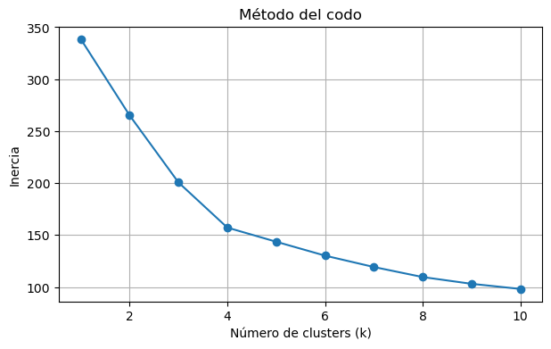

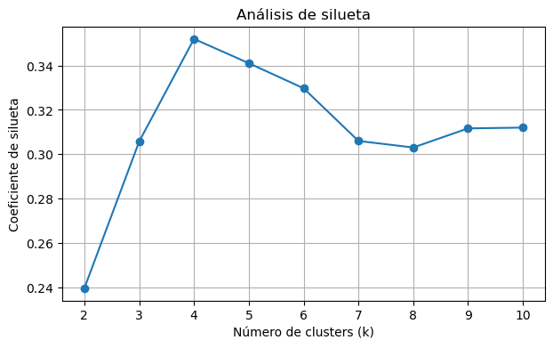

```python
plt.figure(figsize=(7, 4))
plt.plot(k_values, inercias, marker="o")
plt.xlabel("Número de clusters (k)")
plt.ylabel("Inercia")
plt.title("Método del codo")
plt.grid(True)
plt.show()

plt.figure(figsize=(7, 4))
plt.plot(k_values_silueta, siluetas, marker="o")
plt.xlabel("Número de clusters (k)")
plt.ylabel("Coeficiente de silueta")
plt.title("Análisis de silueta")
plt.grid(True)
plt.show()
```

## 5. Aplicación de K-means

Se aplica K-means utilizando la `k` seleccionada a partir del coeficiente de silueta.  
Si se quiere forzar otro valor, se puede modificar manualmente la variable `k_optima`.

```python
k_optima = k_silueta

modelo_kmeans = KMeans(
    n_clusters=k_optima,
    random_state=RANDOM_STATE,
    n_init=20
)

df_clusterizado = df.copy()
df_clusterizado["Cluster"] = modelo_kmeans.fit_predict(X_encoded)

print("k utilizada:", k_optima)
display(df_clusterizado.head(20))
```

```
k utilizada: 4
```

|  | Forma | Numero_lados | Color | Tamano | Direccion | Cluster |
| --- | --- | --- | --- | --- | --- | --- |
| 0 | Triangulo | 3 | Amarillo | Grande | Arriba | 0 |
| 1 | Circulo | 0 | Rojo | Grande | Ninguna | 3 |
| 2 | Rectangulo | 4 | Verde | Mediano | Horizontal | 2 |
| 3 | Triangulo | 3 | Azul | Grande | Derecha | 0 |
| 4 | Cuadrado | 4 | Rojo | Grande | Ninguna | 1 |
| 5 | Cuadrado | 4 | Amarillo | Mediano | Ninguna | 1 |
| 6 | Circulo | 0 | Verde | Mediano | Ninguna | 3 |
| 7 | Rectangulo | 4 | Rojo | Pequeno | Vertical | 2 |
| 8 | Cuadrado | 4 | Verde | Grande | Ninguna | 1 |
| 9 | Triangulo | 3 | Rojo | Grande | Derecha | 0 |
| 10 | Rectangulo | 4 | Amarillo | Mediano | Diagonal ascendente | 2 |
| 11 | Triangulo | 3 | Verde | Pequeno | Arriba | 0 |
| 12 | Circulo | 0 | Amarillo | Mediano | Ninguna | 3 |
| 13 | Rectangulo | 4 | Verde | Grande | Horizontal | 2 |
| 14 | Circulo | 0 | Azul | Grande | Ninguna | 3 |
| 15 | Cuadrado | 4 | Azul | Grande | Ninguna | 1 |
| 16 | Triangulo | 3 | Amarillo | Grande | Arriba | 0 |
| 17 | Triangulo | 3 | Amarillo | Grande | Derecha | 0 |
| 18 | Triangulo | 3 | Amarillo | Mediano | Arriba | 0 |
| 19 | Triangulo | 3 | Amarillo | Grande | Arriba | 0 |

## 6. Análisis de los clusters resultantes

En esta sección se analiza el tamaño de cada cluster y las características predominantes dentro de cada grupo.

```python
print("Tamaño de cada cluster:")
display(df_clusterizado["Cluster"].value_counts().sort_index())

resumen_clusters = (
    df_clusterizado
    .groupby("Cluster")[columnas_esperadas]
    .agg(lambda x: x.mode().iloc[0])
)

resumen_clusters["Num_elementos"] = df_clusterizado.groupby("Cluster").size()

print("Características dominantes por cluster:")
display(resumen_clusters)
```

```
Tamaño de cada cluster:
```

```
Cluster
0    25
1    25
2    25
3    25
Name: count, dtype: int64
```

```
Características dominantes por cluster:
```

| Cluster | Forma | Numero_lados | Color | Tamano | Direccion | Num_elementos |
| --- | --- | --- | --- | --- | --- | --- |
| 0 | Triangulo | 3 | Amarillo | Grande | Arriba | 25 |
| 1 | Cuadrado | 4 | Verde | Grande | Ninguna | 25 |
| 2 | Rectangulo | 4 | Verde | Grande | Horizontal | 25 |
| 3 | Circulo | 0 | Verde | Grande | Ninguna | 25 |

```python
# Tablas cruzadas para entender mejor cada cluster
for atributo in ["Forma", "Color", "Tamano", "Direccion"]:
    print(f"Distribución de {atributo} por cluster:")
    tabla = pd.crosstab(df_clusterizado["Cluster"], df_clusterizado[atributo])
    display(tabla)
```

```
Distribución de Forma por cluster:
```

| Forma Cluster | Circulo | Cuadrado | Rectangulo | Triangulo |
| --- | --- | --- | --- | --- |
| 0 | 0 | 0 | 0 | 25 |
| 1 | 0 | 25 | 0 | 0 |
| 2 | 0 | 0 | 25 | 0 |
| 3 | 25 | 0 | 0 | 0 |

```
Distribución de Color por cluster:
```

| Color Cluster | Amarillo | Azul | Rojo | Verde |
| --- | --- | --- | --- | --- |
| 0 | 7 | 4 | 7 | 7 |
| 1 | 6 | 6 | 6 | 7 |
| 2 | 6 | 3 | 6 | 10 |
| 3 | 6 | 6 | 6 | 7 |

```
Distribución de Tamano por cluster:
```

| Tamano Cluster | Grande | Mediano | Pequeno |
| --- | --- | --- | --- |
| 0 | 15 | 5 | 5 |
| 1 | 17 | 7 | 1 |
| 2 | 12 | 9 | 4 |
| 3 | 12 | 10 | 3 |

```
Distribución de Direccion por cluster:
```

| Direccion Cluster | Arriba | Derecha | Diagonal ascendente | Horizontal | Ninguna | Vertical |
| --- | --- | --- | --- | --- | --- | --- |
| 0 | 13 | 12 | 0 | 0 | 0 | 0 |
| 1 | 0 | 0 | 0 | 0 | 25 | 0 |
| 2 | 0 | 0 | 6 | 13 | 0 | 6 |
| 3 | 0 | 0 | 0 | 0 | 25 | 0 |

## 7. Visualización de los clusters

Para visualizar los resultados se reduce el dataset codificado a dos dimensiones mediante PCA.  
Esta visualización no se usa para entrenar el modelo, solo para representar gráficamente los clusters.

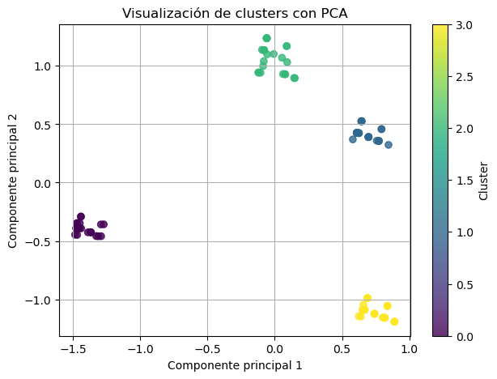

```
Varianza explicada por PC1 y PC2:
```

```
PC1    0.224802
PC2    0.201183
dtype: float64
```

```python
pca = PCA(n_components=2, random_state=RANDOM_STATE)
X_pca = pca.fit_transform(X_encoded)

df_visual = pd.DataFrame({
    "PC1": X_pca[:, 0],
    "PC2": X_pca[:, 1],
    "Cluster": df_clusterizado["Cluster"]
})

plt.figure(figsize=(7, 5))
scatter = plt.scatter(
    df_visual["PC1"],
    df_visual["PC2"],
    c=df_visual["Cluster"],
    alpha=0.8
)
plt.xlabel("Componente principal 1")
plt.ylabel("Componente principal 2")
plt.title("Visualización de clusters con PCA")
plt.grid(True)
plt.colorbar(scatter, label="Cluster")
plt.show()

print("Varianza explicada por PC1 y PC2:")
display(pd.Series(pca.explained_variance_ratio_, index=["PC1", "PC2"]))
```

## 9. Análisis de los resultados

La **k óptima seleccionada fue 4**, ya que tanto el **método del codo** como el **coeficiente de silueta** señalaron este valor como el más adecuado. Antes de aplicar el algoritmo K-means, las variables categóricas del dataset se transformaron mediante **one-hot encoding**, puesto que este algoritmo requiere trabajar con datos numéricos.

El algoritmo agrupó los datos principalmente en función de la **forma geométrica**. Los cuatro clústeres obtenidos se corresponden con los cuatro tipos de figuras presentes en el dataset: **triángulos, círculos, rectángulos y cuadrados**. Cada grupo contiene **25 elementos**, lo que refleja la distribución equilibrada del dataset sintético. Por tanto, la separación realizada por K-means se explica sobre todo por la forma y, de manera secundaria, por atributos relacionados con ella, como el **número de lados** y la **dirección**.

En comparación con el criterio visual utilizado por el LLM, el resultado de K-means se aproxima más al agrupamiento basado en la **geometría** que al basado en el **color**. El LLM podía modificar su criterio según el número de conjuntos solicitado; por ejemplo, al pedir 2 clusters agrupó las figuras según colores cálidos y fríos. En cambio, K-means no separó los datos principalmente por color ni por tamaño, sino por la estructura geométrica de las figuras.

Los grupos obtenidos son coherentes con el dataset original y con el proceso de oversampling realizado. Esto se debe a que el dataset ampliado mantenía una distribución equilibrada de las cuatro formas. Además, se conservan las relaciones lógicas entre atributos: los triángulos tienen 3 lados, los círculos 0, los cuadrados y rectángulos 4, y las direcciones asignadas son compatibles con cada tipo de figura.